# Generalized Additive Models, An Introduction with R

Author

Rick Dean

Abstract

Notes and graphics from the text [Generalized Additive Models, An Introduction with R, Second Edition](https://www.routledge.com/Generalized-Additive-Models-An-Introduction-with-R-Second-Edition/Wood/p/book/9781498728331) by Simon N. Wood. The following R script is following Chapter 1, ‘Linear Models’

Load the Required R Packages:

```r
library(data.table)
library(purrr)
library(ggplot2)
library(here)
library(gt)
library(gamair)
library(magrittr)
library(RplotterPkg)
library(RregressPkg)
library(RmatrixPkg)
```

# Linear Models

## 1.3 The theory of linear models

### 1.3.1 Least squares estimation of $\beta$

We will be using the `gamair::sperm.comp1` data set and *RmatrixPkg::qr_householder()* for performing the QR decomposition. The data set is described in `[Wood, section 1.5.1 page 23]`.

1. Load the data and define the predictor($\textbf{X}$) and response($\textbf{Y}$) matrices:

```r
data("sperm.comp1", package = "gamair")
sperm1_dt <- data.table::as.data.table(sperm.comp1) %>%
  .[, .(count = count, time_ipc = time.ipc, prop_partner = prop.partner)]

n = nrow(sperm1_dt)

X_dt <- data.table(Intercept = rep(1, n)) %>%
  .[, `:=` (time_pc = sperm1_dt$time_ipc, prop_partner = sperm1_dt$prop_partner)]

p = ncol(X_dt) # number of predictors including the intercept

X <- as.matrix(X_dt)                  # n x p
y <- as.matrix(sperm1_dt[, .(count)]) # n x 1
```

2. Perform $\textbf{QR}$ decomposition of $\textbf{X}$ into its components $\textbf{Q}_{f}$ and $\textbf{R}$ `[Wood Equation 1.5 page 12]`

```r
X_qr <- RmatrixPkg::qr_householder(X,complete = T)

Q <- X_qr$Q              # n x n
Qf <- Q[,1:p]            # n x p
R <- X_qr$R[1:p, 1:p]    # p x p
```

Check the decomposition where $\textbf{X} = \textbf{Q}_{f}\textbf{R}$.

```r
Xcheck <- Qf %*% R
```

$\textbf{X} = \begin{pmatrix} 1 & 60 & 0.2 \\ 1 & 149 & 0.98 \\ 1 & 70 & 0.5 \\ 1 & 168 & 0.5 \\ 1 & 48 & 0.2 \\ 1 & 32 & 1 \end{pmatrix}$

$\textbf{Xcheck} = \begin{pmatrix} 1 & 60 & 0.2 \\ 1 & 149 & 0.98 \\ 1 & 70 & 0.5 \\ 1 & 168 & 0.5 \\ 1 & 48 & 0.2 \\ 1 & 32 & 1 \end{pmatrix}$

3. Compute $t(\textbf{Q})\textbf{y}$ and assign vectors $\textbf{f}$ and $\textbf{r}$:

```r
Qy <- t(Q) %*% y                  # n x 1

f <- as.matrix(Qy[1:p,])          # p x 1
r <- as.matrix(Qy[(p + 1):n,])    # n - p x 1
```

We have the following:

- $f$ an $3\space by \space 1$ matrix
- $r$ an $12\space by \space 1$ matrix
4. Estimate the $\beta$’s `[Wood Equation 1.6 page 12]`:

```r
R_inv <- solve(R)               # p x p
beta_hat <- (R_inv %*% f)       # p x 1

dt <- data.table::as.data.table(beta_hat, keep.rownames = T) %>%
  data.table::setnames(., old = colnames(.), new = c("Predictor","Beta"))
RplotterPkg::create_table(
  x = dt,
  decimals_lst = list(cols = c(2), decimal = 2),
  container_width_px = 300
)
```

| Predictor | Beta |
| --- | --- |
| Intercept | 357.42 |
| time_pc | 1.94 |
| prop_partner | −339.56 |

Compare the above betas with $\hat{\beta_{j}}$ at `[Wood, page 27]`

### 1.3.2 The distribution of $\hat{\beta}$

The variance of the betas $var(\hat{\beta})$ are proportional to the unknown $\sigma^2$ variance of $\epsilon_{i}$ where $y_{i} = \beta x_{i} + \epsilon_{i}$ `[Wood Equation 1.3, page 4]`. An unbiased estimator of $\sigma^2$ is from the model’s residuals $\hat{\epsilon_{i}} = y_{i} - x_{i}\hat{\beta}$ where:
$$\hat{\sigma}^2 = \frac{1}{N - 1}\sum(y_{i} - x_{i}\hat{\beta})$$
From `[Wood Equation 1.8, page 13]`:
$$\hat{\sigma}^2 = \frac{||r||^{2}}{(n - p)}$$

```r
sigma_sq <- drop(t(r) %*% r)/(n - p)
```

$\hat{\sigma^{2}}$ variance: 18661.91

Using $\hat{\sigma^{2}}$, Wood derives the covariance matrix of $\hat{\beta}$ `[Wood Equation 1.7, page 13]`:
$$V_{\hat{\beta}} = R^{-1}R^{-T}\hat{\sigma}^{2}$$

```r
Vbeta <- R_inv %*% t(R_inv) * sigma_sq # p x p
```

$\textbf{Vbeta} = \begin{pmatrix} 7758.47 & -39.84 & -7444.88 \\ -39.84 & 0.82 & -20.04 \\ -7444.88 & -20.04 & 15939.94 \end{pmatrix}$

Wood points out the distribution of $\hat{\beta}$:
$$\hat{\beta} \sim N(\beta,V_{\hat{\beta}})$$

### 1.3.3 $(\hat{\beta_{i}} - \beta_{i})/\hat{\sigma}_{\hat{\beta_{i}}} \sim t_{n-p}$

Wood shows that the estimated standard error $\hat{\sigma_{\beta_{i}}}$ are the square root of the diagonal elements of $V_{\hat{\beta}}$.

```r
se_beta <- sqrt(diag(Vbeta))
```

The $\hat{\sigma_{\beta_{i}}}$ standard errors: 88.0821592, 0.9067154, 126.2534581

Further Wood shows that $T_{i} = \hat{\beta_{i}}/\hat{\sigma_{\beta_{i}}}$ is a standardized measure of how far each beta parameter estimate is from zero. Under $H_{0}:\beta_{i} = 0$, $T_{i} \sim t_{n-p}$.

### 1.3.4 $F$-ratio results

Testing if $\beta_{time_ipc}$ and $\beta_{prop_partner}$ = 0 (i.e. **$\beta_{1}$** = 0)

$H_{0}:\beta_{1} = 0$ versus $H_{1}: \beta_{1} \ne 0$

1. Partition **X** into **X_0** and **X_1**:

```r
p = 3
q = 2

X_0 <- X[,1]
X_1 <- X[,2:3]
```

2. Partition **f** and compute the increase in residual sum of squares that results from dropping **X_1**:

```r
f_0 <- f[1]
f_1 <- f[2:3]

sse_minus_beta_1 <- (t(f_1) %*% f_1)[1,1]
```

3. Compute $F$ which follows an $F$ distribution with *q* (2) and *n - p* (12) degrees of freedom:

```r
F_val <- (sse_minus_beta_1/q)/sigma_sq
```

$F$ = 5.0562461

4. Compute the $F$ critical value with 2 and 12 df at 1% level

```r
F_cv <- qf(1 - 0.01, 2,12)
```

$F_{q,n-p}$ = 6.9266081

## 1.5 Practical linear modeling

### 1.5.1 Model fitting and model checking

Load and plot the raw data.

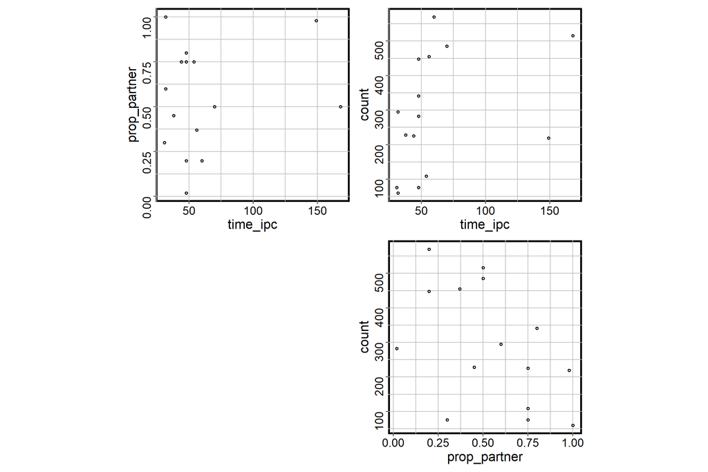

Pair plot of sperm competition data

```r
data("sperm.comp1", package = "gamair")
sperm1_dt <- data.table::as.data.table(sperm.comp1) %>%
  .[, .(subject = subject, count = count, time_ipc = time.ipc, prop_partner = prop.partner)]

RregressPkg::plot_pairs(
  df = sperm1_dt,
  var_name_scaling = list(
    time_ipc = NULL,
    prop_partner = NULL,
    count = NULL
  ),
  axis_text_sz = 14,
  plot_dim = 20
)
```

There appears to some decrease in sperm count (*count*) as proportion of time spent together (*prop_partner*) increases.

Define the initial linear model.

```r
sperm1_ols_lst <- RregressPkg::ols_calc(
  df = sperm1_dt,
  formula_obj = count ~ time_ipc + prop_partner
)

RplotterPkg::create_table(
  x = sperm1_ols_lst$coef_df,
  container_width_px = 400
)
```

| Coef | Value | SE | t_value | p_Value |
| --- | --- | --- | --- | --- |
| (Intercept) | 357.418434 | 88.0821592 | 4.057785 | 0.001588001 |
| time_ipc | 1.941609 | 0.9067154 | 2.141366 | 0.053460688 |
| prop_partner | -339.560170 | 126.2534581 | -2.689512 | 0.019687611 |

Check the model.

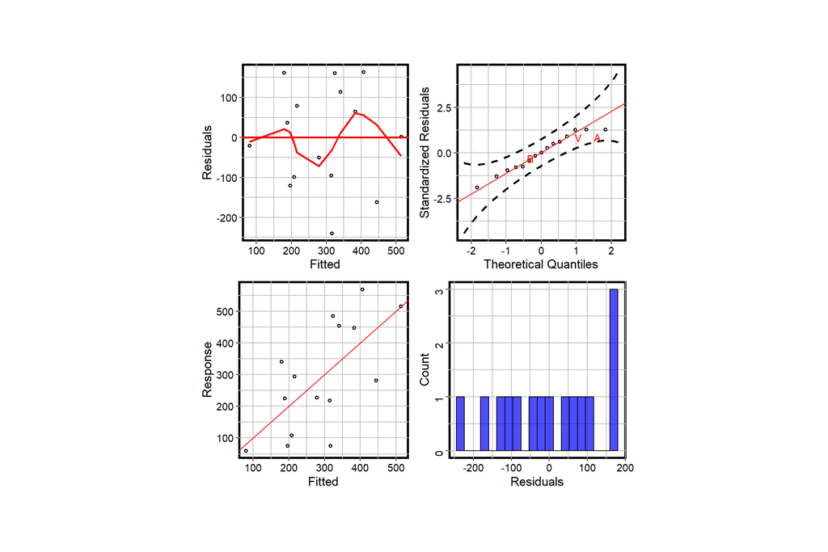

Model checking plots for the linear model: count ~ time_ipc + prop_partner

```r
RregressPkg::plot_model_check(
  fitted_v = sperm1_ols_lst$fitted_vals,
  response_v = sperm1_dt$count,
  residual_v = sperm1_ols_lst$residual_vals,
  id_v = sperm1_dt$subject,
  histo_fill = "blue",
  histo_alpha = 0.7
)
```